# automobiles

HImanshu Pareek

August 27, 2017

Loading data into R

```r
#accessing file
filename <- "AUTOMOBILES.csv"
automobiles <- read.csv(filename, na.strings = c("NA", "na", "not available", "NOT AVAILABLE", "Not Available", "?", "-", "_", "null", "NULL"))
head (automobiles)
```

```
##   symboling normalized.losses        make fuel.type aspiration
## 1         3                NA alfa-romero       gas        std
## 2         3                NA alfa-romero       gas        std
## 3         1                NA alfa-romero       gas        std
## 4         2               164        audi       gas        std
## 5         2               164        audi       gas        std
## 6         2                NA        audi       gas        std
##   num.of.doors  body.style drive.wheels engine.location wheel.base length
## 1          two convertible          rwd           front       88.6  168.8
## 2          two convertible          rwd           front       88.6  168.8
## 3          two   hatchback          rwd           front       94.5  171.2
## 4         four       sedan          fwd           front       99.8  176.6
## 5         four       sedan          4wd           front       99.4  176.6
## 6          two       sedan          fwd           front       99.8  177.3
##   width height curb.weight engine.type num.of.cylinders engine.size
```

[output cut: 20 more lines]

Data with na values

```r
naData <- automobiles[rowSums(is.na(automobiles)) > 0, ]
head (naData)
```

```
##    symboling normalized.losses        make fuel.type aspiration
## 1          3                NA alfa-romero       gas        std
## 2          3                NA alfa-romero       gas        std
## 3          1                NA alfa-romero       gas        std
## 6          2                NA        audi       gas        std
## 8          1                NA        audi       gas        std
## 10         0                NA        audi       gas      turbo
##    num.of.doors  body.style drive.wheels engine.location wheel.base length
## 1           two convertible          rwd           front       88.6  168.8
## 2           two convertible          rwd           front       88.6  168.8
## 3           two   hatchback          rwd           front       94.5  171.2
## 6           two       sedan          fwd           front       99.8  177.3
## 8          four       wagon          fwd           front      105.8  192.7
## 10          two   hatchback          4wd           front       99.5  178.2
##    width height curb.weight engine.type num.of.cylinders engine.size
```

[output cut: 20 more lines]

Remove na valued data from automobiles

```r
automobiles <- na.omit(automobiles)
head (automobiles)
```

```
##    symboling normalized.losses make fuel.type aspiration num.of.doors
## 4          2               164 audi       gas        std         four
## 5          2               164 audi       gas        std         four
## 7          1               158 audi       gas        std         four
## 9          1               158 audi       gas      turbo         four
## 11         2               192  bmw       gas        std          two
## 12         0               192  bmw       gas        std         four
##    body.style drive.wheels engine.location wheel.base length width height
## 4       sedan          fwd           front       99.8  176.6  66.2   54.3
## 5       sedan          4wd           front       99.4  176.6  66.4   54.3
## 7       sedan          fwd           front      105.8  192.7  71.4   55.7
## 9       sedan          fwd           front      105.8  192.7  71.4   55.9
## 11      sedan          rwd           front      101.2  176.8  64.8   54.3
## 12      sedan          rwd           front      101.2  176.8  64.8   54.3
##    curb.weight engine.type num.of.cylinders engine.size fuel.system bore
## 4         2337         ohc             four         109        mpfi 3.19
## 5         2824         ohc             five         136        mpfi 3.19
## 7         2844         ohc             five         136        mpfi 3.19
## 9         3086         ohc             five         131        mpfi 3.13
## 11        2395         ohc             four         108        mpfi 3.50
## 12        2395         ohc             four         108        mpfi 3.50
##    stroke compression.ratio horsepower peak.rpm city.mpg highway.mpg price
## 4     3.4              10.0        102     5500       24          30 13950
## 5     3.4               8.0        115     5500       18          22 17450
## 7     3.4               8.5        110     5500       19          25 17710
## 9     3.4               8.3        140     5500       17          20 23875
## 11    2.8               8.8        101     5800       23          29 16430
## 12    2.8               8.8        101     5800       23          29 16925
```

Change column names for ease of access

```r
colNames <- c("symboling", "normalized_lossed", "make", "fuel_type", "aspiration",
              "doors", "body_style", "drive_wheels", "engine_loc", "wheel_base",
              "length", "width", "height", "curb_weight", "engine_type", "noc",
              "engine_size", "fuel_system", "bore", "stroke", "comp_ratio", "hp",
              "peak_rpm", "city_mpg", "high_mpg", "price")
colnames(automobiles) <- colNames
head (automobiles)
```

```
##    symboling normalized_lossed make fuel_type aspiration doors body_style
## 4          2               164 audi       gas        std  four      sedan
## 5          2               164 audi       gas        std  four      sedan
## 7          1               158 audi       gas        std  four      sedan
## 9          1               158 audi       gas      turbo  four      sedan
## 11         2               192  bmw       gas        std   two      sedan
## 12         0               192  bmw       gas        std  four      sedan
##    drive_wheels engine_loc wheel_base length width height curb_weight
## 4           fwd      front       99.8  176.6  66.2   54.3        2337
## 5           4wd      front       99.4  176.6  66.4   54.3        2824
## 7           fwd      front      105.8  192.7  71.4   55.7        2844
## 9           fwd      front      105.8  192.7  71.4   55.9        3086
## 11          rwd      front      101.2  176.8  64.8   54.3        2395
## 12          rwd      front      101.2  176.8  64.8   54.3        2395
##    engine_type  noc engine_size fuel_system bore stroke comp_ratio  hp
## 4          ohc four         109        mpfi 3.19    3.4       10.0 102
## 5          ohc five         136        mpfi 3.19    3.4        8.0 115
## 7          ohc five         136        mpfi 3.19    3.4        8.5 110
## 9          ohc five         131        mpfi 3.13    3.4        8.3 140
## 11         ohc four         108        mpfi 3.50    2.8        8.8 101
## 12         ohc four         108        mpfi 3.50    2.8        8.8 101
##    peak_rpm city_mpg high_mpg price
## 4      5500       24       30 13950
## 5      5500       18       22 17450
## 7      5500       19       25 17710
## 9      5500       17       20 23875
## 11     5800       23       29 16430
## 12     5800       23       29 16925
```

Class of different columns of automobiles data

```r
colClasses <- sapply(automobiles, class)
colClasses
```

```
##         symboling normalized_lossed              make         fuel_type
##         "integer"         "integer"          "factor"          "factor"
##        aspiration             doors        body_style      drive_wheels
##          "factor"          "factor"          "factor"          "factor"
##        engine_loc        wheel_base            length             width
##          "factor"         "numeric"         "numeric"         "numeric"
##            height       curb_weight       engine_type               noc
##         "numeric"         "integer"          "factor"          "factor"
##       engine_size       fuel_system              bore            stroke
##         "integer"          "factor"         "numeric"         "numeric"
##        comp_ratio                hp          peak_rpm          city_mpg
##         "numeric"         "integer"         "integer"         "integer"
##          high_mpg             price
##         "integer"         "integer"
```

According to NOIR topology, category of data are symboling - Nominal normalized_losses - Interval make - Nominal fuel_type - Nominal aspiration - Nominal doors - Ordinal body_style - Nominal drive_wheels - Nominal engine_loc - Nominal wheele_base - Interval length - Interval width - Interval height - Interval curb_weight - Interval engine_type - Nominal noc - Ordinal engine_size - Interval fuel_system - Nominal bore - Interval stroke - Interval comp_ratio - Rational hp - Interval peak_rpm - Interval city_mpg - Interval high_mpg - Interval prive - Interval

We will take the following attributes 1. Nominal - make 2. Ordinal - noc 3. Interval - length 4. Rational - comp_ratio

## 1. Nominal (make)

subsetting data

```r
make_data <- subset(automobiles, select = make)
head (make_data)
```

```
##    make
## 4  audi
## 5  audi
## 7  audi
## 9  audi
## 11  bmw
## 12  bmw
```

grouping data

```r
library (dplyr)
make_data <- group_by (make_data, make)
head (make_data)
```

```
## # A tibble: 6 x 1
## # Groups:   make [2]
##     make
##   <fctr>
## 1   audi
## 2   audi
## 3   audi
## 4   audi
## 5    bmw
## 6    bmw
```

making count of each factor

```r
make_data <- summarize(make_data, count = n())
head (make_data)
```

```
## # A tibble: 6 x 2
##        make count
##      <fctr> <int>
## 1      audi     4
## 2       bmw     4
## 3 chevrolet     3
## 4     dodge     8
## 5     honda    13
## 6    jaguar     1
```

Pie chart

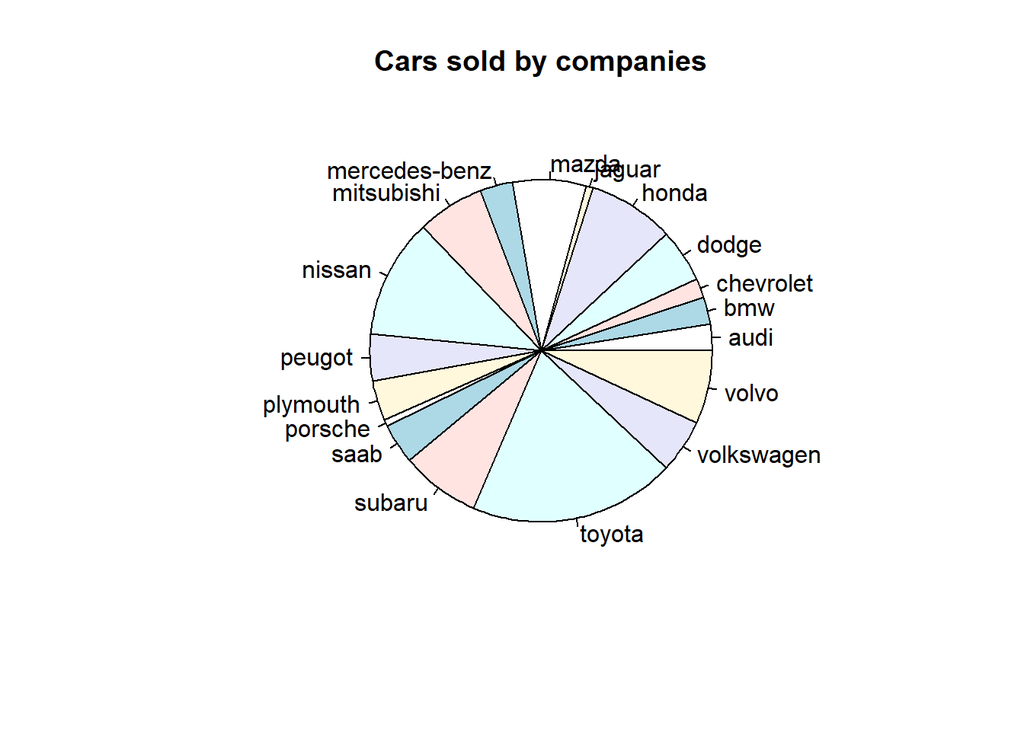

```r
pie(make_data$count, labels = make_data$make, main = "Cars sold by companies")
```

Bar plot

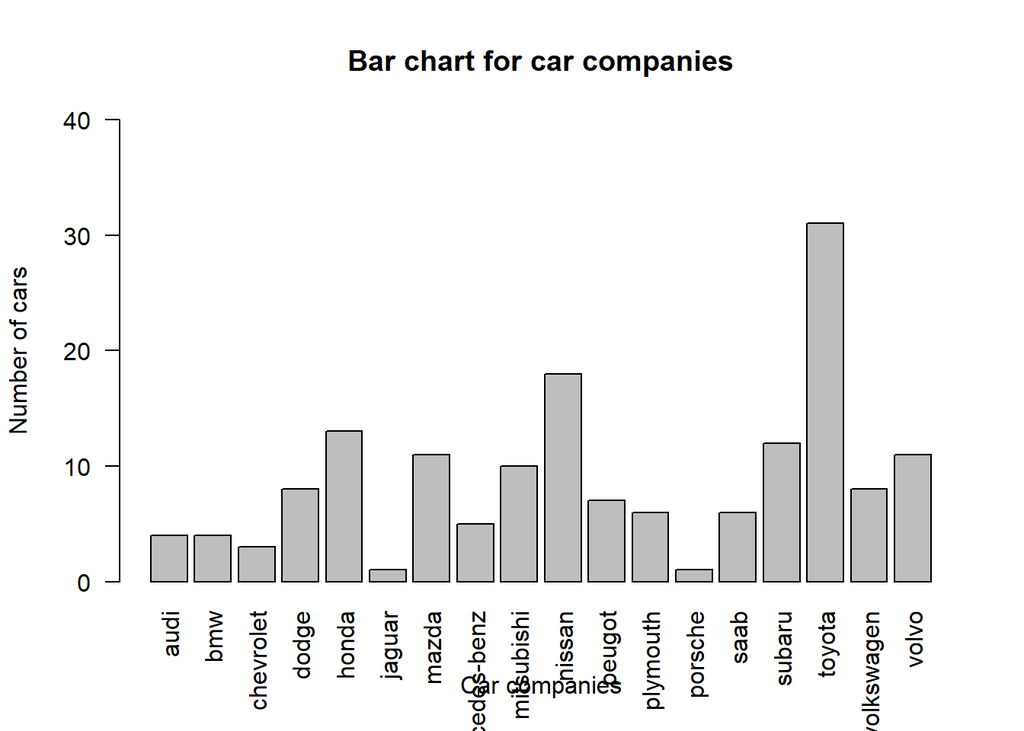

```r
barplot(make_data$count, names.arg = make_data$make, main = "Bar chart for car companies",
        xlab = "Car companies", ylab = "Number of cars", las = 2, ylim = c(0, 40))
```

Line chart

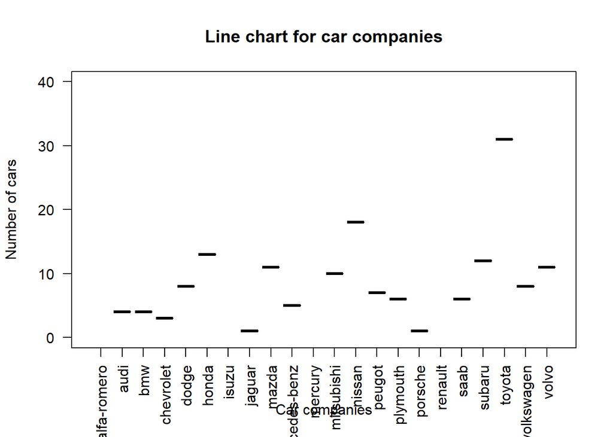

```r
plot(make_data$make, make_data$count,
     main = "Line chart for car companies",
     xlab = "Car companies",
     ylab = "Number of cars", las = 2, ylim = c(0, 40))
```

We can see that maximum number of cars has been sold by ‘toyota’, i.e. mode of this distribution is toyota

## 2. Ordinal (number_of_cylinders)

sbsetting data

```r
noc_data <- subset(automobiles, select = noc)
head (noc_data)
```

```
##     noc
## 4  four
## 5  five
## 7  five
## 9  five
## 11 four
## 12 four
```

grouping data

```r
noc_data <- group_by(noc_data, noc)
noc_data <- summarize(noc_data, count = n())
head (noc_data)
```

```
## # A tibble: 5 x 2
##      noc count
##   <fctr> <int>
## 1  eight     1
## 2   five     7
## 3   four   136
## 4    six    14
## 5  three     1
```

vector to order the factors

```r
numOfCyls <- c("one" = 1,
               "two" = 2,
               "three" = 3,
               "four" = 4,
               "five" = 5,
               "six" = 6,
               "seven" = 7,
               "eight" = 8,
               "nine" = 9,
               "ten" = 10
            )
```

extra column to set order of noc

```r
noc_data$noc <- as.character(noc_data$noc)
noc_data <- mutate(noc_data, lab = numOfCyls[noc])
head (noc_data)
```

```
## # A tibble: 5 x 3
##     noc count   lab
##   <chr> <int> <dbl>
## 1 eight     1     8
## 2  five     7     5
## 3  four   136     4
## 4   six    14     6
## 5 three     1     3
```

sorting w.r.t. lab (noc)

```r
noc_data <- arrange(noc_data, lab)
noc_data
```

```
## # A tibble: 5 x 3
##     noc count   lab
##   <chr> <int> <dbl>
## 1 three     1     3
## 2  four   136     4
## 3  five     7     5
## 4   six    14     6
## 5 eight     1     8
```

removing lab column from noc_data

```r
noc_data$noc <- noc_data$lab
noc_data <- subset (noc_data, select = -lab)
noc_data
```

```
## # A tibble: 5 x 2
##     noc count
##   <dbl> <int>
## 1     3     1
## 2     4   136
## 3     5     7
## 4     6    14
## 5     8     1
```

Line plot

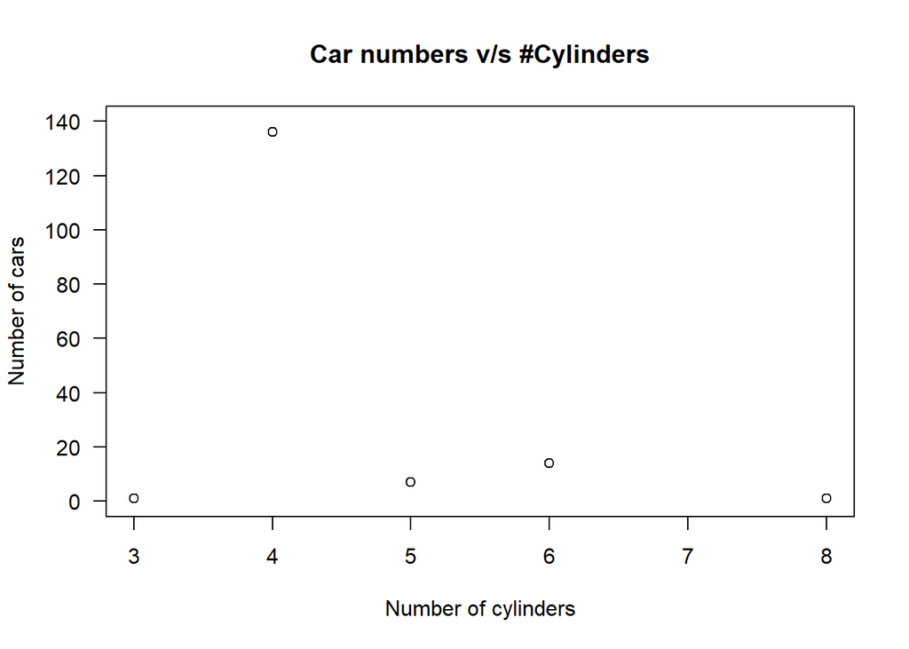

```r
plot(noc_data$noc, noc_data$count, main = "Car numbers v/s #Cylinders",
     xlab = "Number of cylinders", ylab = "Number of cars", las = 1,
     ylim = c(0, 140))
```

Pie chart

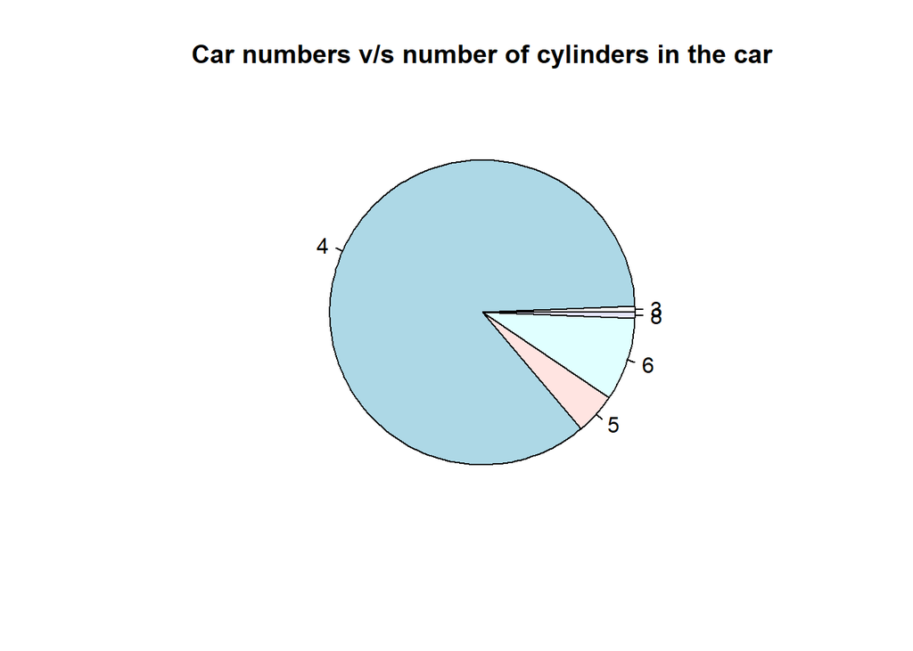

```r
pie(noc_data$count, labels = noc_data$noc,
    main = "Car numbers v/s number of cylinders in the car")
```

Bar plot

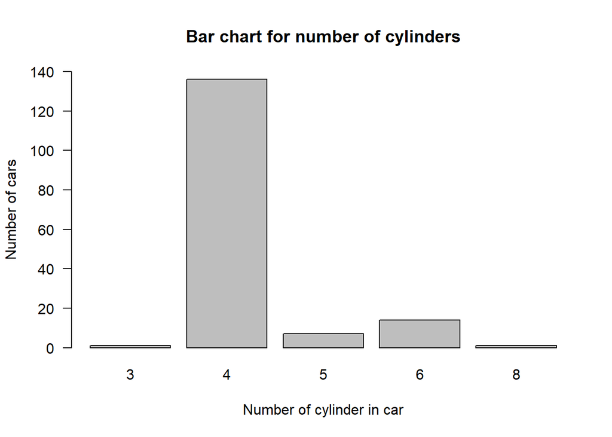

```r
barplot(noc_data$count, names.arg = noc_data$noc, main = "Bar chart for number of cylinders",
        xlab = "Number of cylinder in car", ylab = "Number of cars", las = 1, ylim = c(0, 140))
```

We can see taht maximum number of cars correspond to 4 cylinders in the car, so mode is 4.

## 3. Interval (length)

subsetting data

```r
length_data <- subset(automobiles, select = length)
head (length_data)
```

```
##    length
## 4   176.6
## 5   176.6
## 7   192.7
## 9   192.7
## 11  176.8
## 12  176.8
```

Histogram of length of cars

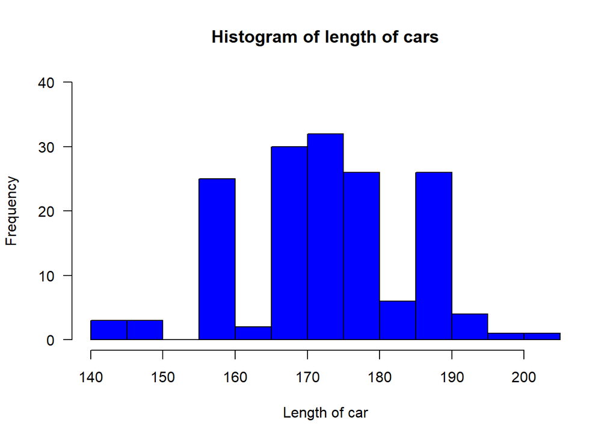

```r
hist (length_data$length,
      col = "blue",
      main = "Histogram of length of cars",
      ylim = c(0, 40),
      xlab = "Length of car",
      las = 1)
```

Calculate mean, variance and standard deviation

```r
mean_len <- mean(length_data$length)
var_len <- var(length_data$length)
sd_len <- sd(length_data$length)
sprintf("%s ===> %f", c("Mean", "Variance", "Standard deiation"), c(mean_len, var_len, sd_len))
```

```
## [1] "Mean ===> 172.413836"             "Variance ===> 132.783605"
## [3] "Standard deiation ===> 11.523177"
```

Calculate q-values (5 points)

```r
q <- quantile(length_data$length, probs = c(0, 0.25, 0.50, 0.75, 1.0))
q
```

```
##     0%    25%    50%    75%   100%
## 141.10 165.65 172.40 177.80 202.60
```

We observe that mean is 172.413836, median is 172.40 and mod is 172.50 (approximately)

## 4: Rational - comp_ratio

subsetting data

```r
comp_data <- subset(automobiles, select = comp_ratio)
head (comp_data)
```

```
##    comp_ratio
## 4        10.0
## 5         8.0
## 7         8.5
## 9         8.3
## 11        8.8
## 12        8.8
```

Histogram of compression ratio

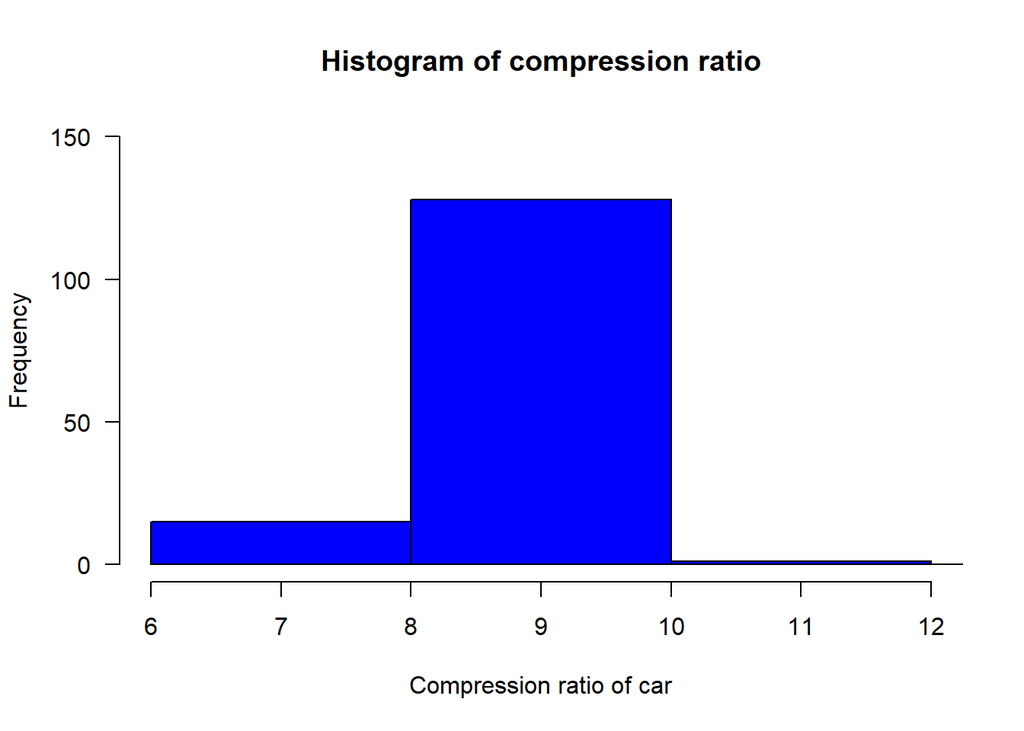

```r
hist (comp_data$comp_ratio,
      col = "blue",
      main = "Histogram of compression ratio",
      ylim = c(0, 150),
      xlim = c(6, 12),
      xlab = "Compression ratio of car",
      las = 1)
```

Another histogram

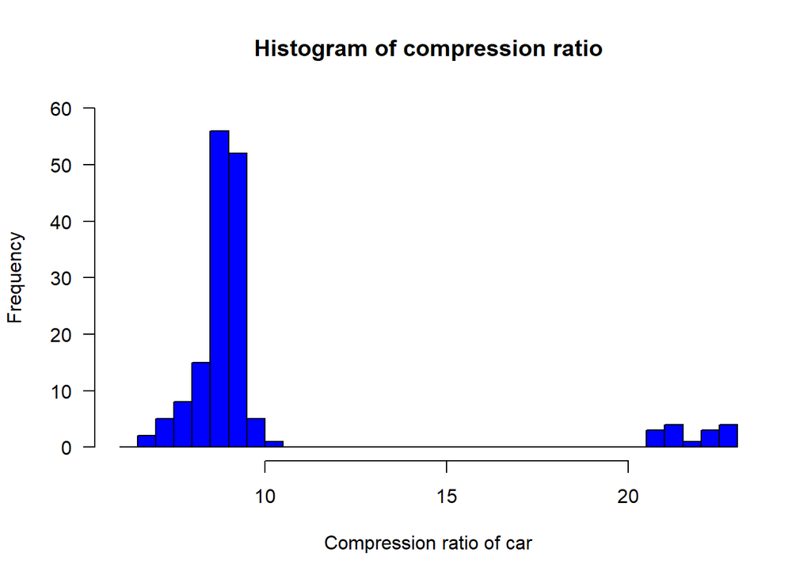

```r
hist (comp_data$comp_ratio,
      col = "blue",
      main = "Histogram of compression ratio",
      ylim = c(0, 60),
      xlab = "Compression ratio of car",
      breaks = seq(6, 23, 0.5),
      las = 1)
```

Another hsitogram

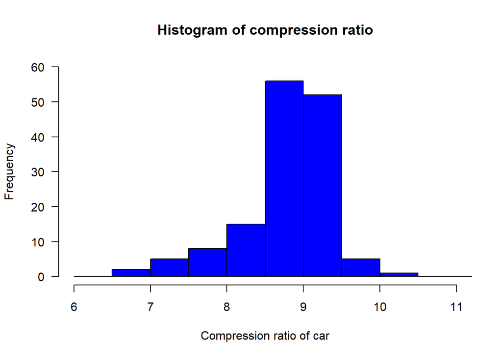

```r
hist (comp_data$comp_ratio,
      col = "blue",
      main = "Histogram of compression ratio",
      ylim = c(0, 60),
      xlim = c(6, 11),
      xlab = "Compression ratio of car",
      breaks = seq(6, 23, 0.5),
      las = 1)
```

Another histogram

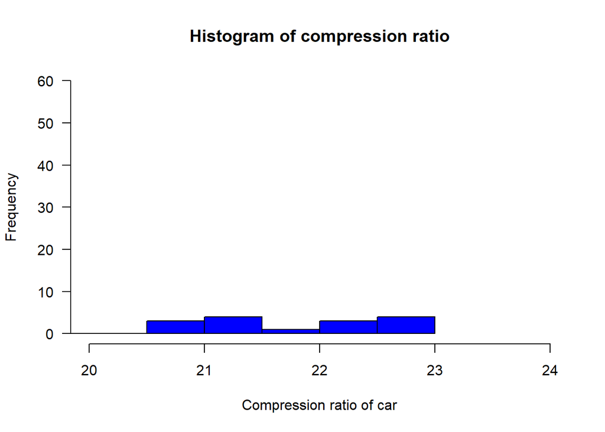

```r
hist (comp_data$comp_ratio,
      col = "blue",
      main = "Histogram of compression ratio",
      ylim = c(0, 60),
      xlim = c(20, 24),
      xlab = "Compression ratio of car",
      breaks = seq(6, 23, 0.5),
      las = 1)
```

Calculate mean, variance and standard deviation

```r
mean_comp <- mean(comp_data$comp_ratio)
var_comp <- var(comp_data$comp_ratio)
sd_comp <- sd(comp_data$comp_ratio)
sprintf("%s ===> %f", c("Mean", "Variance", "Standard deiation"), c(mean_comp, var_comp, sd_comp))
```

```
## [1] "Mean ===> 10.161132"             "Variance ===> 15.128013"
## [3] "Standard deiation ===> 3.889475"
```

Calculate q-values (5 points)

```r
q <- quantile(comp_data$comp_ratio, probs = c(0, 0.25, 0.50, 0.75, 1.0))
q
```

```
##   0%  25%  50%  75% 100%
##  7.0  8.7  9.0  9.4 23.0
```

We observe that mean is 10.161132, median is 9.0 and mode is 8.75 (approximately)

## Peak RPM

subsetting data

```r
peak_data <- subset(automobiles, select = peak_rpm)
head (peak_data)
```

```
##    peak_rpm
## 4      5500
## 5      5500
## 7      5500
## 9      5500
## 11     5800
## 12     5800
```

Histogram of peak rpm

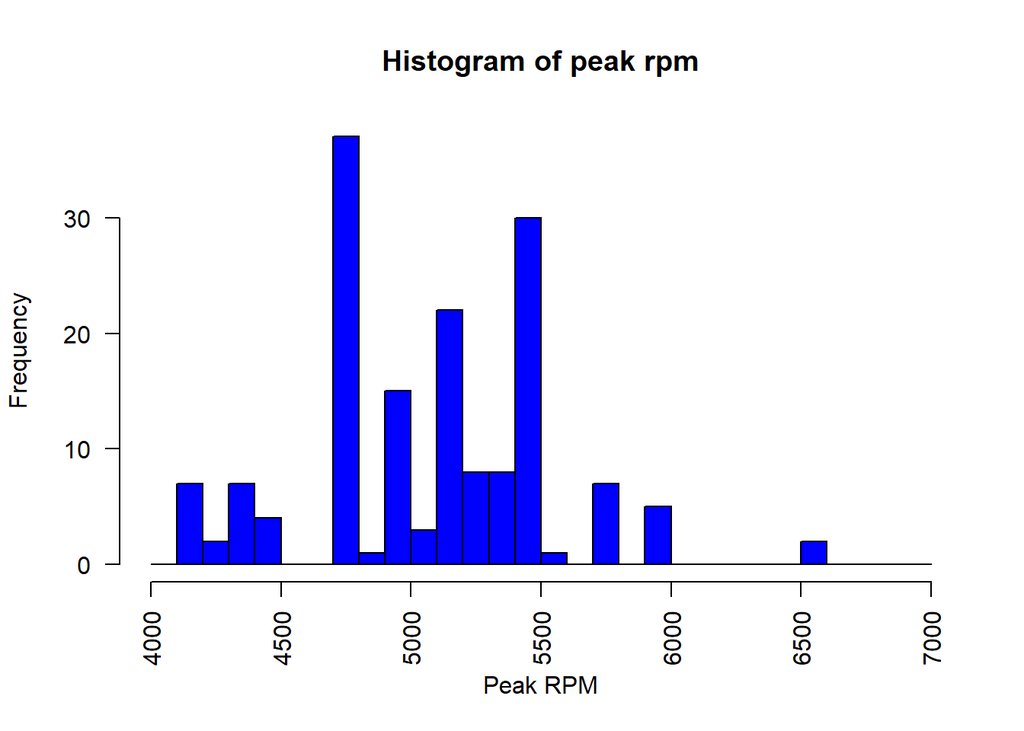

```r
hist (peak_data$peak_rpm,
      col = "blue",
      main = "Histogram of peak rpm",
      xlab = "Peak RPM",
      las = 2,
      breaks = seq(4000, 7000, 100))
```

Calculate mean, variance and standard deviation

```r
mean_pr <- mean(peak_data$peak_rpm)
var_pr <- var(peak_data$peak_rpm)
sd_pr <- sd(peak_data$peak_rpm)
sprintf("%s ===> %f", c("Mean", "Variance", "Standard deviation"), c(mean_pr, var_pr, sd_pr))
```

```
## [1] "Mean ===> 5113.836478"
## [2] "Variance ===> 216927.593344"
## [3] "Standard deviation ===> 465.754864"
```

Calculate q-values (5 points)

```r
q <- quantile(peak_data$peak_rpm, probs = c(0, 0.25, 0.50, 0.75, 1.0))
q
```

```
##   0%  25%  50%  75% 100%
## 4150 4800 5200 5500 6600
```

We observe that mean is 5113.836478, median is 5200 and mode is 4750 (approximately)

## City MPG

subsetting data

```r
city_mpg <- subset (automobiles, select = city_mpg)
head (city_mpg)
```

```
##    city_mpg
## 4        24
## 5        18
## 7        19
## 9        17
## 11       23
## 12       23
```

Histogram of city mpg

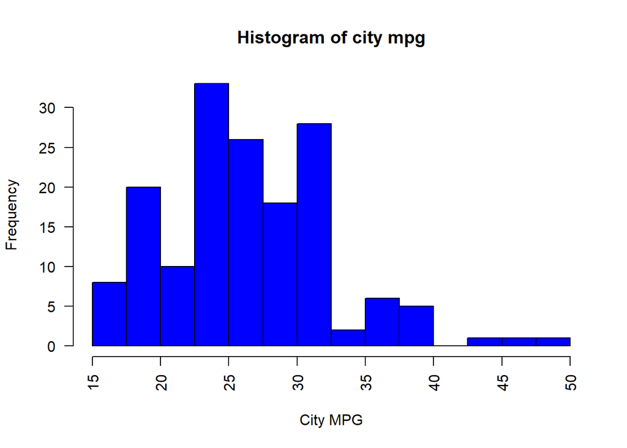

```r
hist (city_mpg$city_mpg,
      col = "blue",
      main = "Histogram of city mpg",
      xlab = "City MPG",
      breaks = seq(15.0, 50.0, 2.5),
      las = 2)
```

Calculate mean, variance and standard deviation

```r
mean_cm <- mean (city_mpg$city_mpg)
var_cm <- var (city_mpg$city_mpg)
sd_cm <- sd (city_mpg$city_mpg)
sprintf ("%s ===> %f", c("Mean", "Variance", "Standard deviation"),
         c(mean_cm, var_cm, sd_cm))
```

```
## [1] "Mean ===> 26.522013"              "Variance ===> 37.175145"
## [3] "Standard deviation ===> 6.097142"
```

Calculating q-values (5 points)

```r
q <- quantile (city_mpg$city_mpg, probs = c(0, 0.25, 0.50, 0.75, 1.0))
q
```

```
##   0%  25%  50%  75% 100%
##   15   23   26   31   49
```